# presentation-live

## Kat×Kat: bublinové počty

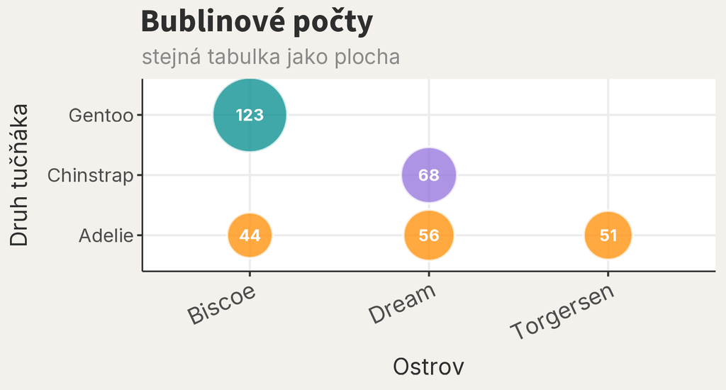

Bubliny jsou efektní, ale porovnávání ploch je pro oko těžší než porovnávání délek.

## Kat×Kat: počty nebo podíly?

Počty

Kdy potřebujeme vědět, kolik pozorování opravdu máme?

Podíly

Kdy nás zajímá složení skupiny bez ohledu na její velikost?

## Co rozhoduje?

Číselná osa

Chceme číst vztah dvou hodnot.

Skupiny

Chceme porovnat rozložení mezi kategoriemi.

Kombinace kategorií

Chceme počty nebo podíly.

Nejdřív se zeptejte: jakého typu je proměnná A a jakého typu je proměnná B?

## Shrnutí základních vizualizací

| Proměnná A | Proměnná B | Možné typy grafu |
| --- | --- | --- |
| kvantitativní | kvantitativní | bodový graf; bodový graf s barvou, přímkou nebo hustotou |
| kvantitativní | kategoriální | body ve skupinách; boxplot; violin plot |
| kategoriální | kategoriální | tabulka četností; waffle plot; skupinové nebo skládané sloupce |

# Co dál?

## Co přidá model?

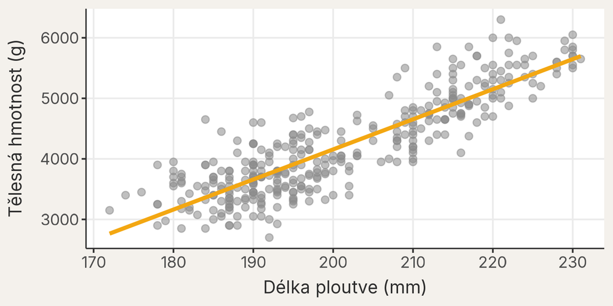

Přímka přidá odhad efektu: o kolik gramů se typicky mění hmotnost na každý 1 mm délky ploutve? To bude téma následující lekce.

## Shrnutí

- Pro dvě numerické proměnné je první volbou bodový graf.
- Z grafu čteme současně směr vztahu i šířku rozptylu.
- Korelace vztah shrne číslem, ale nenahradí samotný graf.
- Viditelný vzor ještě není důkaz efektu.
- Model přidá velikost efektu a jeho nejistotu.

Co ještě potřebujeme?

Co nám schází k tomu, abychom z viditelného vzoru přešli k přesnějšímu tvrzení o velikosti efektu a nejistotě?

1. Větší dataset a více bodů v grafu.
2. Model: v následující lekci přidá odhad efektu a potom jeho interval spolehlivosti.
3. Silnější korelaci, aby bylo číslo přesvědčivější.

Řekněte sousedovi jednou větou

Co model přidá, co korelace neumí?